# DAKUI -NOTE 5-The Numerical Renormalization Group Method

## The Numerical Renormalization Group

### Quantum impurity

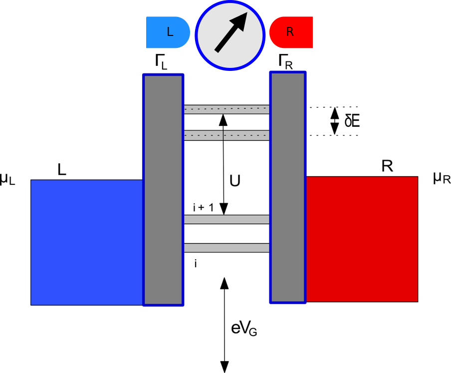

• point-like object with a local degree of freedom example: spin & orbital angular momentum of a magnetic dopant atom

• environment = continuum of states example: itinerant electrons in a metal

• interaction that can change the value of local d.o.f. example: exchange coupling & spin-flip scattering

### The Numerical Renormalization Group

Approximately the six consecutive steps is required to delineate the mechanism of the NRG method:

1. Logarithmic division of the conduction band. This was the first step in the derivation and the most important one, it will lead to killing the logarithmic divergence mentioned in The Kondo Effect post. The conduction band is split into intervals that decrease towards low energies:$ \pm [ \Lambda^{-n-1}, \Lambda^{-n} ].$
1. Fourier expansion of each interval, using orthogonal basis functions that are zero outside the interval.
1. Approximating by using only the Wannier orbital centered on the impurity. It turns out that the impurity couples directly only to the fundamental harmonic, the other terms couple only indirectly through the first term and decouple in the limit $\Lambda\rightarrow 1$.
1. Lanczos tridiagonalization: Wilson chain. The previous step ended up with the impurity coupled to a p=0 term for each interval, in order to be able to solve it iteratively, it is tridiagonalized using the Lanczos algorithm. The result is the impurity coupled to a single site which in turn couples to the next one and so on, the couplings decreasing exponentially. This ensures a energy scale separation at each step.
2. The renormalization group transform. A recursion relation is obtained: $H_{N+1}=\sqrt{\Lambda}H_N + \Lambda^{N/2} \sum\limits_\sigma (t f^\dagger_{\sigma , N} f_{\sigma , N+1} + h.c.)$ that allows to define a renormalization group transform $H_{N+1} = R(H_N)$.
1. Iteration with truncation of the eigenvalues and eigenvectors. Because the Hilbert space grows exponentially one cannot keep up all states and energies while new sites are added, a truncation scheme is applied. The high energy states that are discarded do not affect the low energy states that are added. Each step corresponds to an energy scale and also to a temperature.

We will follow the principle line outlined above and unravel the mysteries behind the story.

#### Quantum impurity

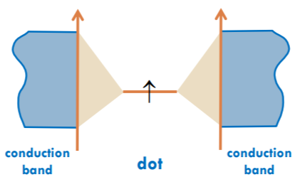

The Hamiltonian of a general quantum impurity model consists of three parts, the impurity$ H_{imp}$, the bath $H_{bath}$, and the impurity-bath interaction $H_{imp-bath}$.

$$ H=H_{\mathrm{imp}}+H_{\mathrm{bath}}+H_{\mathrm{imp}-\mathrm{bath}} $$

For the single-impurity Anderson model with the Hamiltonian H=HSIAM, these three terms are given by

$$ \begin{aligned} &H_{\mathrm{imp}}=\sum_{\sigma} \varepsilon_{f} f_{\sigma}^{\dagger} f_{\sigma}+U f_{\uparrow}^{\dagger} f_{\uparrow} f_{\dot{\downarrow}}^{\dagger} f_{\downarrow}\\ &H_{\mathrm{bath}}=\sum_{k \sigma} \varepsilon_{k} c_{k \sigma}^{\dagger} c_{k \sigma}\\ &H_{\mathrm{imp}-\mathrm{bath}}=\sum_{k \sigma} V_{k}\left(f_{\sigma}^{\dagger} c_{k \sigma}+c_{k a}^{\dagger} f_{\sigma}\right) \end{aligned} $$

For simplicity the mapping of a single level AM reads, in which we consider a CB with a spin- and energy-dependent density of states (DoS) ρ [$ \rho_{\sigma}(\epsilon)=\sum_{\mathbf{k}} \delta\left(\omega-\epsilon_{\mathbf{k} \sigma}\right) $].

$$ \hat{\mathcal{H}}_{A M}=\hat{\mathcal{H}}_{d}+\underbrace{\sum_{\mathbf{k} \sigma} \epsilon_{\mathbf{k} \sigma} c_{\mathbf{k} \sigma}^{\dagger} c_{\mathbf{k} \sigma}}_{\hat{\mathcal{H}}_{C B}}+\underbrace{\sum_{\mathbf{k} \sigma} V_{\mathbf{k} \sigma}\left(c_{\mathbf{k} \sigma}^{\dagger} d_{\sigma}+d_{\sigma}^{\dagger} c_{\mathbf{k} \sigma}\right)}_{\hat{\mathcal{H}}_{\ell d}} $$

#### 1.Manipulating into an effective model

It shuold be noticed that we are truly interested in the impurity contributions to the physics of the SIAM, we can reformulate the Hamiltonian in a variety of ways, provided the main idea is captured. The influence of the bath on the impurity is completely determined by the hybridization function $\Delta (\omega)$. $$ \Delta(\omega)=\pi \sum_{k} V_{k}^{2} \delta\left(\omega-\varepsilon_{k}\right) $$

So the form of $\Delta (\omega)$ should be retained under the manipulation. The manipulation relevant here is just the continuation where we replace the k-sums by a continuous representation.

$$ \begin{aligned} \hat{\mathcal{H}}_{C B} &=\sum_{\sigma} \int_{-1}^{1} d \epsilon g_{\sigma}(\epsilon) a_{\epsilon \sigma}^{\dagger} a_{\epsilon \sigma} \\ \hat{\mathcal{H}}_{\ell d} &=\sum_{\sigma} \int_{-1}^{1} d \epsilon h_{\sigma}(\epsilon)\left(d_{\sigma}^{\dagger} a_{\epsilon \sigma}+\mathrm{h.c.}\right) \end{aligned} $$

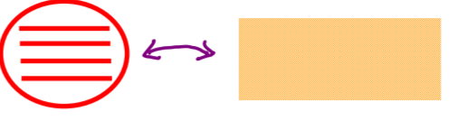

$$ \frac{\partial g_{\sigma}^{-1}(\epsilon)}{\partial \epsilon}\left[h_{\sigma}\left(g_{\sigma}^{-1}(\epsilon)\right)\right]^{2}=\rho_{\sigma}(\epsilon)\left[V_{\sigma}(\epsilon)\right]^{2}---Eq. (1) $$

The requirement should be fulfilled so that the discrete and the continuous representation of the AM are identical. Obviously, there are many possibilities to satisfy the requirement.One possibility is to choose the dispersion $ g_{\sigma}(\epsilon)=g_{\sigma}^{-1}(\epsilon)=C $ and the generalized hybridization $ h_{\sigma}(\epsilon)=\sqrt{\Delta_{\sigma}(\epsilon) / \pi} $, with ²-dependent hybridization $ \Delta_{\sigma}(\epsilon) \equiv \pi \rho_{\sigma}(\epsilon)\left[V_{\sigma}(\epsilon)\right]^{2} $. For reasons that will become clear below, this choice is well suited for a constant (or at least sufficiently smooth) hybridization $\Delta_{\sigma}(\epsilon)$. For a hybridization with a strong energy-dependence , however, the functions $g_{\sigma}(\epsilon)$ and $h_{\sigma}(\epsilon)$ are chosen differently.

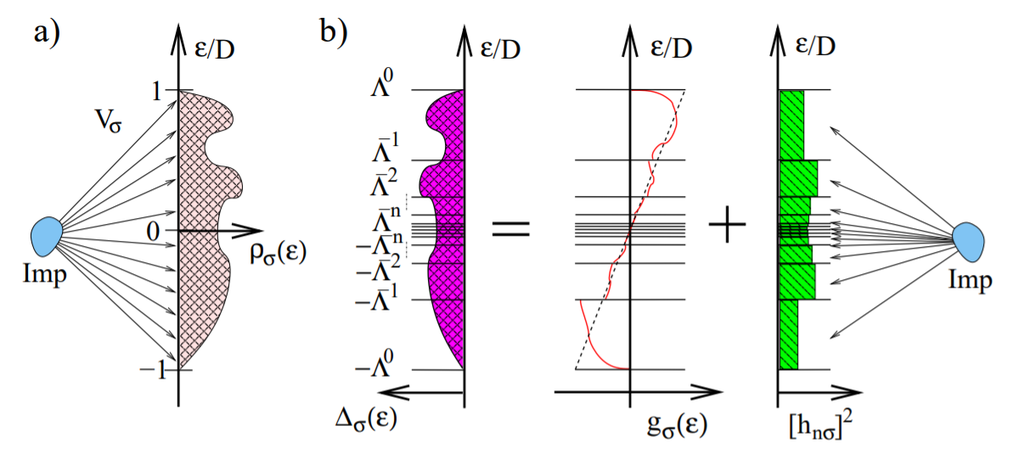

Figure A.1: (a) Since the impurity couples to all energies, the CB is logarithmically discretized (with discretization parameter Λ. (b) For an energy-dependent hybridization $\Delta_{\sigma}(\epsilon)$(left) one chooses the generalized hybridization $h_{\sigma}(\epsilon)= h^{\pm}$ to be constant in each logarithmic interval; for this choice only the (p = 0)-component of the CB couples to the impurity (right panel). The corresponding dispersion $g_{\sigma}(\epsilon)$ , sketched in the middle panel (solid line), follows from solving the equation. For reference the linear dispersion $g_{\sigma}(\epsilon)= \epsilon $ (dashed line) is ploted as well.

#### 2.Logarithmic discretization and fourier transformation

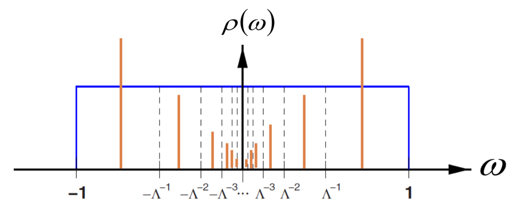

> discretize the conduction electron density of states. Replace the continuous spectrum by discretized poles

The parameter $\Lambda>1$ defines a set of intervals with discretization points

$$ x_{n}=\pm \Lambda^{-n}, \quad n=0,1,2, \dots $$

The width of the intervals is given by

$$ d_{n}=\Lambda^{-n}\left(1-\Lambda^{-1}\right) $$

Within each interval we now introduce a complete set of orthonormal functions

$$ \psi_{n p}^{\pm}(\varepsilon)=\left\{\begin{array}{ll} {\frac{1}{\sqrt{d_{n}}} e^{\pm i \omega_{n} p \varepsilon}} & {\text { for } x_{n+1}<\pm \varepsilon<x_{n}} \\ {0} & {\text { outside this interval. }} \end{array}\right. $$

The index p takes all integer values between $ -\infty $ and $ -\infty $, and the fundamental frequencies for each interval are given by $ \omega_{n}=2 \pi / d_{n} $. The next step is to reformulate the story in this basis.

$$ a_{\varepsilon \sigma}=\sum_{n p}\left[a_{n p \sigma} \psi_{n p}^{+}(\varepsilon)+b_{n p \sigma} \psi_{n p}^{-}(\varepsilon)\right] $$

The inverse transformation reads

$$ \begin{aligned} &a_{n p \sigma}=\int_{-1}^{1} d \varepsilon\left[\psi_{n p}^{+}(\varepsilon)\right]^{*} a_{\varepsilon \sigma}\\ &b_{n p \sigma}=\int_{-1}^{1} d \varepsilon\left[\psi_{n p}^{-}(\varepsilon)\right]^{*} a_{\varepsilon \sigma} \end{aligned} $$

1. Transformation of $H_{ld}$

$$ \hat{\mathcal{H}}_{\ell d}=\sum_{n p \sigma}\left\{\left[d_{\sigma}^{\dagger}\left(a_{n p \sigma} \int_{\Lambda-(n+1)}^{\Lambda-n} d \epsilon h_{\sigma}(\epsilon) \Psi_{n p}^{+}(\epsilon)+b_{n p \sigma} \int_{-\Lambda^{-n}}^{-\Lambda^{-(n+1)}} d \epsilon h_{\sigma}(\epsilon) \Psi_{n p}^{-}(\epsilon)\right)\right]+\mathrm{h.c.}\right\} $$

Henceforth, we take the generalized hybridization function $h_{\sigma}(\epsilon)$ to be constant in all logarithmic intervals, $h_{\sigma}(\epsilon)= h^{\pm}$ , which ensures that the impurity couples to s-waves only, i.e. to the (p = 0)-contributions (Riemann-Lebesgue Lemma).

> [proof : In particular, the transformed hybridization term first part reads, $$ \begin{aligned} \int_{-1}^{1} d \varepsilon h(\varepsilon) d _{\sigma}^{\dagger} a_{\varepsilon \sigma}= d_{\sigma}^{\dagger} \sum_{n p}\left[a_{n p \sigma} \int^{+, n} d \varepsilon h(\varepsilon) \psi_{n p}^{+}(\varepsilon)\right. \left.+b_{n p \sigma} \int^{-, n} d \varepsilon h(\varepsilon) \psi_{n p}^{-}(\varepsilon)\right] \end{aligned} $$ where, $$ \int^{+, n} d \varepsilon \equiv \int_{x_{n+1}}^{x_{n}} d \varepsilon, \quad \int^{-, n} d \varepsilon \equiv \int_{-x_{n}}^{-x_{n+1}} d \varepsilon $$ For a constant $h_{\sigma}(\epsilon)= h^{\pm}$, the integrals filter out the p= 0 component only. $$ \int^{\pm, n} d \varepsilon h \psi_{n p}^{\pm}(\varepsilon)=\sqrt{d_{n}} h \delta_{p, 0} $$ In other words, the impurity couples only to the p= 0 components of the conduction band states. It will become clear soon that this point was essential in Wilson’s original line of arguments, so we maintain this feature $h_{\sigma}(\epsilon)$ being constant in each interval of the logarithmic discretization also for a general, nonconstant $\Delta_{\sigma}(\epsilon)$ . ]

Consequently the harmonic index p can be dropped . This particular choice of the generalized hybridization function, the averaged hybridization function forces us to adjust the generalized dispersion $g_{\sigma}(\epsilon)$ such that Eq. (1) still holds.

$$ \begin{aligned} &h_{n \sigma}^{+} \equiv\left\{\begin{array}{ll} {\sqrt{\frac{1}{d_{n}} \int_{\Lambda_{-}^{-}(n+1)}^{\Lambda-n} d \epsilon \rho_{\sigma}(\epsilon)\left[V_{\sigma}(\epsilon)\right]^{2}}} & {\text { if } \Lambda^{-(n+1)}<\epsilon \leq \Lambda^{-n}} \\ {0} & {\text { else }} \end{array}\right.\\ &h_{n \sigma}^{-} \equiv\left\{\begin{array}{ll} {\sqrt{\frac{1}{d_{n}} \int_{-\Lambda^{-n}}^{-\Lambda^{-(n+1)}} d \epsilon \rho_{\sigma}(\epsilon)\left[V_{\sigma}(\epsilon)\right]^{2}}} & {\text { if }-\Lambda^{-n}<\epsilon \leq-\Lambda^{-(n+1)}} \\ {0} & {\text { else }} \end{array}\right. \end{aligned} $$

In general, as indicated in Fig. A.1(b), this results in a nonlinear generalized dispersion $g_{\sigma}(\epsilon)$.

Finally, the simplified expression is obtained after the persistent efforts.

$$ \hat{\mathcal{H}}_{\ell d}=\sqrt{\frac{1}{\pi}} \sum_{\sigma}\left[d_{\sigma}^{\dagger} \overbrace{\sum_{n}\left(\gamma_{n \sigma}^{+} a_{n \sigma}+\gamma_{n \sigma}^{-} b_{n \sigma}\right)}^{\sim f_{0 \sigma}}+\mathrm{h.c.}\right] $$$$ \gamma_{n \sigma}^{+} \equiv \sqrt{\int_{\Lambda^{-(n+1)}}^{\Lambda-n} d \epsilon \Delta_{\sigma}(\epsilon)} , \gamma_{n \sigma}^{-} \equiv \sqrt{\int_{-\Lambda^{-n}}^{-\Lambda^{-(n+1)}} d \epsilon \Delta_{\sigma}(\epsilon)} $$$$ f_{0 \sigma} \equiv \frac{1}{\sqrt{\vartheta_{0 \sigma}}} \sum_{n}\left(\gamma_{n \sigma}^{+} a_{n \sigma}+\gamma_{n \sigma}^{-} b_{n \sigma}\right) $$$$ \xi_{0 \sigma}=\sum_{n}\left[\left(\gamma_{n \sigma}^{+}\right)^{2}+\left(\gamma_{n \sigma}^{-}\right)^{2}\right]=\int_{-1}^{1} \Delta_{\sigma}(\epsilon) d \epsilon $$

The operator $f_{0 \sigma}$ creates a spin $\sigma $electron in the maximally localized state (which is essentially the conduction electron field on the impurity site), equivalent to the zeroth site of the Wilson chain. In the limit of constant hybridization,$\Delta_{\sigma}(\epsilon)=\Delta_{\sigma}$, the well-known result is reproduced.

$$ f_{0 \sigma}=\sum_{n=0}^{\infty} \sqrt{d_{n} / 2}\left(a_{n \sigma}+b_{n \sigma}\right)=\sqrt{\left(1-\Lambda^{-1}\right) / 2} \sum_{n=0}^{\infty} \Lambda^{-n / 2}\left(a_{n \sigma}+b_{n \sigma}\right) $$

Finally, we get the illustrated rresult which expounds the impurity couples to a single fermionic degree of freedom only, the zeroth site of the Wilson chain. To fully map $H_{AM}$ on a linear chain,however, still $H_{CB}$ needs to be transformed properly.

$$ \hat{\mathcal{H}}_{\ell d}=\sum_{\sigma}\left[\sqrt{\frac{\xi_{0 \sigma}}{\pi}}\left(d_{\sigma}^{\dagger} f_{0 \sigma}+\mathrm{h.c.}\right)\right] $$

##### Transformation of $ H_{CB} $

$$ \hat{\mathcal{H}}_{C B}=\sum_{\sigma} \int_{-1}^{1} d \epsilon g_{\sigma}(\epsilon)\left\{\sum_{n p p^{\prime}}\left[a_{n p \sigma}^{\dagger}\left[\Psi_{n p}^{+}(\epsilon)\right]^{*} a_{n p^{\prime} \sigma} \Psi_{n p^{\prime}}^{+}(\epsilon)+b_{n p \sigma}^{\dagger}\left[\Psi_{n p}^{-}(\epsilon)\right]^{*} b_{n p^{\prime} \sigma} \Psi_{n p^{\prime}}^{-}(\epsilon)\right]\right\} $$

Though only (p = 0)-contributions couple directly to the impurity (p= 0)-contributions might play a role by an indirect coupling to the impurity [via the (p = 0)-mode]. Therefore two contributions remain in the pp -sum .

$$ \sum_{p=0, p^{\prime}}[\ldots]=[\ldots]_{p=0, p^{\prime}=0}+[\ldots]_{ p^{\prime}\neq 0} $$

The pp=0 contribution take the form of

$$ \hat{\mathcal{H}}_{C B}^{(1)}=\sum_{n \sigma}\left[\xi_{n \sigma}^{+} a_{n \sigma}^{\dagger} a_{n \sigma}+\xi_{n \sigma}^{-} b_{n \sigma}^{\dagger} b_{n \sigma}\right] $$$$ \xi_{n \sigma}^{+}=\left(1 / d_{n}\right) \int_{\Lambda_{-}(n+1)}^{\Lambda-n} d \epsilon g_{\sigma}(\epsilon) \text { and } ,\xi_{n \sigma}^{-}=\left(1 / d_{n}\right) \int_{-\Lambda^{-n}}^{-\Lambda^{-(n+1)}} d \epsilon g_{\sigma}(\epsilon) $$

Note the following: since the single-particle energies of the CB electrons $\xi_{n \sigma}^{\pm}$ depend only on the integral over the logarithmic intervals an exact knowledge of $g_{\sigma}(\epsilon)$ is not required. Bulla et al. showed that for the particular choice taken here [ $h_{\sigma}(\epsilon)= h^{\pm}$ in each logarithmic interval], the single-particle energies $\xi_{n \sigma}^{\pm}$ are given by

$$ \begin{aligned} &\xi_{n \sigma}^{+} \equiv \frac{\int_{\Lambda-(n+1)}^{\Lambda^{-n}} d \epsilon \epsilon \Delta_{\sigma}(\epsilon)}{\int_{\Lambda^{-(n+1)}}^{\Lambda^{-n}} d \epsilon \Delta_{\sigma}(\epsilon)}\\ &\xi_{n \sigma}^{-} \equiv \frac{\int_{-\Lambda^{-n}}^{-\Lambda^{-(n+1)}} d \epsilon \epsilon \Delta_{\sigma}(\epsilon)}{\int_{-\Lambda^{-n}}^{-\Lambda^{-} n} d \epsilon \Delta_{\sigma}(\epsilon)} \end{aligned} $$

A straightforward comparison reveals that the dispersion is indeed nonlinear here.

$$ g_{\sigma}(\epsilon)=\epsilon\left\{\left[d_{n} \Delta_{\sigma}(\epsilon)\right] /\left[\int_{\Lambda^{-(n+1)}}^{\Lambda-n} d \epsilon \Delta_{\sigma}(\epsilon)\right]\right\} $$

For constant hybridization $\Delta_{\sigma}(\epsilon)=\Delta_{\sigma}$ the linear dispersion [$g_{\sigma}(\epsilon)= \epsilon $] is recovered within this more general framework.

$$ \hat{\mathcal{H}}_{C B}^{(1)}=\frac{1}{2}\left(1+\Lambda^{-1}\right) \sum_{n \sigma} \Lambda^{-n}\left(a_{n \sigma}^{\dagger} a_{n \sigma}-b_{n \sigma}^{\dagger} b_{n \sigma}\right) $$$$ \xi_{n \sigma}^{\pm}=\pm \frac{1}{2}\left(1+\Lambda^{-1}\right) \Lambda^{-n} $$

The $pp\neq 0$ can be showed to be less and less important for Λ approaching 1 so it is justified to dropped the higher order term.

By now ,the intriguing equation behaves in its own way.

$$ H=H_{d}+H_{CB}+H_{ld}=H_{d}+\sum_{n \sigma}\left[\xi_{n \sigma}^{+} a_{n \sigma}^{\dagger} a_{n \sigma}+\xi_{n \sigma}^{-} b_{n \sigma}^{\dagger} b_{n \sigma}\right]+\sqrt{\frac{1}{\pi}} \sum_{\sigma}\left[d_{\sigma}^{\dagger} \overbrace{\sum_{n}\left(\gamma_{n \sigma}^{+} a_{n \sigma}+\gamma_{n \sigma}^{-} b_{n \sigma}\right)}^{\sim f_{0 \sigma}}+\mathrm{h.c.}\right] $$

#### 3. Mapping onto a semi-infinite chain ---Tridiagnalize

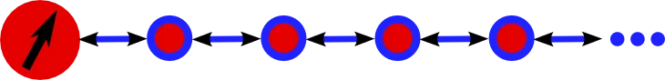

To solve $H_{AM}$ numerically, it is convenient to bring $H_{CB}$ , into tridiagonal from[to map Hˆ CB onto a semi-infinite chain (the Wilson chain $H_{W C}$], $$ \underbrace{\sum_{n=0}^{\infty}\left(\xi_{n \sigma}^{+} a_{n \sigma}^{\dagger} a_{n \sigma}+\xi_{n \sigma}^{\dagger} b_{n \sigma}^{\dagger} b_{n \sigma}\right)}_{\hat{\mathcal{H}}_{C B}}=\underbrace{\sum_{n=0}^{\infty}\left[\epsilon_{n \sigma} f_{n \sigma}^{\dagger} f_{n \sigma}+t_{n \sigma}\left(f_{n \sigma}^{\dagger} f_{n+1 \sigma}+f_{n+1 \sigma}^{\dagger} f_{n \sigma}\right)\right]}_{\hat{\mathcal{H}}_{W C}}---Eq. (A.3) $$

$$ H=H_{0}\left(d_{\sigma}^{\dagger}, \underbrace{d_{\sigma}}_{f_{0 \sigma}}\right)+\sum_{\varepsilon \sigma} \varepsilon c_{\varepsilon \sigma}^{\dagger} c_{\varepsilon \sigma}+v\left[\sum_{\sigma} d_{\sigma}^{\dagger} \underbrace{\sum_{\varepsilon} c_{\varepsilon \sigma}}_{f_{1 \sigma}}+\mathrm{h.c.}\right] $$$$ \left[\begin{array}{cccc} {\oplus} & {\cdots} & {\cdots} & {\cdots} \\ {\vdots} & {\ddots} & {O} \\ {\vdots} & {0} & {\ddots} \end{array}\right] \quad \frac{\text { tridiagonalize }}{ }\left[\begin{array}{cccc} {\oplus} & & & \\ & {\ddots}{\ddots}{\ddots} & \\ & & {\ddots}{\ddots}{\ddots} & \\ & & & {\ddots}{\ddots}{\ddots}\\ \end{array}\right] $$

> L´anczos tridiagonalization procedure : $$ \left|\Psi_{n \sigma}\right\rangle= f_{n \sigma}^{\dagger}|0\rangle $$ with Fock vacuum $|0\rangle, n \in \mathbb{N}_{0}$ $$ \begin{aligned} \hat{\mathcal{H}}_{C B}\left|\Psi_{n \sigma}\right\rangle=\overbrace{\left\langle\Psi_{n \sigma}\left|\hat{\mathcal{H}}_{C B}\right| \Psi_{n \sigma}\right\rangle}^{\epsilon_{n \sigma}}\left|\Psi_{n \sigma}\right\rangle &+\overbrace{\left\langle\Psi_{n-1 \sigma}\left|\hat{\mathcal{H}}_{C B}\right| \Psi_{n \sigma}\right\rangle}^{t_{n-1 \sigma}}\left|\Psi_{n-1 \sigma}\right\rangle \\ &+\overbrace{\left\langle\Psi_{n+1 \sigma}\left|\hat{\mathcal{H}}_{C B}\right| \Psi_{n \sigma}\right\rangle}^{t_{n \sigma}\left|\Psi_{n \sigma}\right\rangle}\left|\Psi_{n+1 \sigma}\right\rangle \end{aligned}---Eq. (A.2) $$

We can immediately identify the matrix elements $\epsilon_{n \sigma}, t_{n−1,\sigma}$ and $t_{n,\sigma}$ by comparing Eq. (A.3) with the ansatz Eq. (A.2). Eq. (A.3) nicely illustrates that the n-th site of the Wilson chain is only connected to its two neighboring sites, the (n − 1)-th and the (n + 1)-th site of the chain. It can also nicely be seen that the recursive determination of the fermionic operators $f_{n \sigma }$ involves the calculation of the onsite energies and the hopping matrix elements along the Wilson chain.

Let's execute the calculation carefully.

$$ H=H_{d}+H_{CB}+H_{ld}\\ =H_{d}+\sum_{n \sigma}\left[\xi_{n \sigma}^{+} a_{n \sigma}^{\dagger} a_{n \sigma}+\xi_{n \sigma}^{-} b_{n \sigma}^{\dagger} b_{n \sigma}\right]+\sqrt{\frac{1}{\pi}} \sum_{\sigma}\left[d_{\sigma}^{\dagger} \overbrace{\sum_{n}\left(\gamma_{n \sigma}^{+} a_{n \sigma}+\gamma_{n \sigma}^{-} b_{n \sigma}\right)}^{\sim f_{0 \sigma}}+\mathrm{h.c.}\right]\\ = H_{\mathrm{d}}+\sum_{\sigma n=0}^{\infty}\left[\varepsilon_{n} f_{n \sigma}^{\dagger} f_{n \sigma} +t_{n}\left(f_{n \sigma}^{\dagger} f_{n+1 \sigma}+f_{n+1 \sigma}^{\dagger} f_{n \sigma}\right)\right]+\sqrt{\frac{\xi_{0}}{\pi}} \sum_{\sigma}\left(d_{\sigma}^{\dagger} f_{0 \sigma}+f_{0 \sigma}^{\dagger} d_{\sigma}\right) $$

Next we perform the orthogonal transformation.

$$a_{n \sigma}=\sum_{m=0}^{\infty} u_{m n} f_{m \sigma}, \quad b_{n \sigma}=\sum_{m=0}^{\infty} v_{m n} f_{m \sigma}$$$$f_{n \sigma}=\sum_{m=0}^{\infty}\left(u_{n m} a_{m \sigma}+v_{n m} b_{m \sigma}\right)$$

A simple look at the 0-term we obtain the 0-order coefficients. $$ f_{0 \sigma} \equiv \frac{1}{\sqrt{\xi_{0 \sigma}}} \sum_{n}\left(\gamma_{n \sigma}^{+} a_{n \sigma}+\gamma_{n \sigma}^{-} b_{n \sigma}\right) $$

$$ u_{0 m}=\frac{\gamma_{m}^{+}}{\sqrt{\xi_{0}}}, \quad v_{0 m}=\frac{\gamma_{m}^{-}}{\sqrt{\xi_{0}}} $$

Next, we derive recursion relations following the standard scheme.

$$ \begin{array}{l} {\sum_{n \sigma}\left(\xi_{n}^{+} a_{n \sigma}^{\dagger} a_{n \sigma}+\xi_{n} b_{n \sigma}^{\dagger} b_{n \sigma}\right)} {\quad=\sum_{\sigma n=0}^{\infty}\left[\varepsilon_{n} f_{n \sigma}^{\dagger}f_{n \sigma}+t_{n}\left(f_{n \sigma}^{\dagger} f_{n+1 \sigma}+c_{n+1 \sigma}^{\dagger} f_{n \sigma}\right)\right]} \end{array} $$

> $$ f_{n \sigma}=\sum_{m=0}^{\infty}\left(u_{n m \sigma} a_{m \sigma}+v_{n m \sigma} b_{m \sigma}\right) $$$$a_{n \sigma}=\sum_{m=0}^{\infty} u_{m n} f_{m \sigma}, \quad b_{n \sigma}=\sum_{m=0}^{\infty} v_{m n} f_{m \sigma}$$

> Putting the $a_{n \sigma}$ term and the $b_{n \sigma}$ term into the expression yields. $$ \sum_{m=0}^{\infty}\left(\xi_{m s}^{+} u_{n m \sigma} a_{m \sigma}^{\dagger}+\xi_{m s}^{-} v_{n m \sigma} b_{m \sigma}^{\dagger}\right)=\epsilon_{n \sigma} f_{n \sigma}^{\dagger}+t_{n \sigma} f_{n+1 \sigma}^{\dagger}+t_{n-1 \sigma} f_{n-1 \sigma}^{\dagger} $$ The first term (n=0) follows: $$ u_{0 m \sigma}=\frac{\gamma_{m \sigma}^{+}}{\sqrt{\xi_{0 \sigma}}}, \quad v_{0 m \sigma}=\frac{\gamma_{m \sigma}^{-}}{\sqrt{\xi_{0 \sigma}}}---Eq. (a) $$ $$ \sum_{m=0}^{\infty}\left(\frac{\xi_{m \sigma}^{+} \gamma_{m \sigma}^{+}}{\sqrt{\xi_{0 \sigma}}} a_{m \sigma}^{\dagger}+\frac{\xi _{m \sigma}^{-} \gamma_{m \sigma}^{-}}{\sqrt{\xi_{0 \sigma}}} b_{m \sigma}^{\dagger}\right)=\epsilon_{0 \sigma} f_{0 \sigma}^{\dagger}+t_{0 \sigma} f_{1 \sigma}^{\dagger} $$ Impose the anticommutation relationship on the both sides. $ \left\{f_{n \sigma}, f_{n^{\prime} \sigma^{\prime}}^{\dagger}\right\}=\delta_{n n^{\prime}} \delta_{\sigma \sigma^{\prime}} $ One obtains $$ \epsilon_{0 \sigma}=\frac{1}{\xi_{0 \sigma}} \sum_{m}\left[\xi _{m \sigma}^{+}\left(\gamma_{m \sigma}^{+}\right)^{2}+\xi _{m \sigma}^{-}\left(\gamma_{m \sigma}^{-}\right)^{2}\right] $$ Similarly the same trick works, $$ \left\{\epsilon_{0 \sigma} f_{0 \sigma}^{\dagger}+t_{0 \sigma} f_{1 \sigma}^{\dagger}, \epsilon_{0 \sigma} f_{0 \sigma}+t_{0 \sigma} f_{1 \sigma}\right\}=\left(\epsilon_{0 \sigma}\right)^{2}+\left(t_{0 \sigma}\right)^{2}= \sum_{m}\left\{\left(\frac{\xi_{m \sigma}^{+} \gamma_{m \sigma}^{+}}{\sqrt{\xi_{0 \sigma}}} a_{m \sigma}^{\dagger}+\frac{\xi_{m \sigma}^{-} \gamma_{m \sigma}^{-}}{\sqrt{\xi_{0 \sigma}}} b_{m \sigma}^{\dagger}\right),\left(\frac{\xi_{m \sigma}^{+} \gamma_{m \sigma}^{+}}{\sqrt{\xi_{0 \sigma}}} a_{m \sigma}^{\dagger}+\frac{\xi_{m \sigma}^{-} \gamma_{m \sigma}^{-}}{\sqrt{\xi_{0 \sigma}}} b_{m \sigma}^{\dagger}\right)^{\dagger}\right\} $$ $$ \left(t_{0 \sigma}\right)^{2}=\frac{1}{\xi_{0 \sigma}}\left\{\sum_{m}\left[\left(\xi_{m \sigma}^{+}\right)^{2}\left(\gamma_{m \sigma}^{+}\right)^{2}+\left(\xi_{m \sigma}^{-}\right)^{2}\left(\gamma_{m \sigma}^{-}\right)^{2}\right]-\sum_{m}\left[\xi_{m \sigma}^{+}\left(\gamma_{m \sigma}^{+}\right)^{2}+\xi_{m \sigma}^{-}\left(\gamma_{m \sigma}^{-}\right)^{2}\right]\right\} $$ Insert the results into the ---Eq. (a), we finnaly get the desired coefficients by a simple comparison with the definition. $$ \begin{aligned} &u_{1 m \sigma}=\frac{\gamma_{m \sigma}^{+}}{\sqrt{\vartheta_{0 \sigma}} t_{0 \sigma}}\left(\xi_{m \sigma}^{+}-\epsilon_{0 \sigma}\right)\\ &v_{1 m \sigma}=\frac{\gamma_{m \sigma}^{-}}{\sqrt{\vartheta_{0 \sigma}} t_{0 \sigma}}\left(\xi_{m \sigma}^{-}-\epsilon_{0 \sigma}\right) \end{aligned} $$

The recursion relations are initialized by

$$ \begin{aligned} &\varepsilon_{0}=\frac{1}{\xi_{0}} \int_{-1}^{1} d \varepsilon \Delta(\varepsilon) \varepsilon\\ &t_{0}^{2}=\frac{1}{\xi_{0}} \sum_{m}\left[\left(\xi_{m}^{+}-\varepsilon_{0}\right)^{2}\left(\gamma_{m}^{+}\right)^{2}+\left(\xi_{m}-\varepsilon_{0}\right)^{2}\left(\gamma_{m}^{-}\right)^{2}\right]\\ &u_{1 m}=\frac{1}{t_{0}}\left(\xi_{m}^{+}-\varepsilon_{0}\right) u_{0 m}\\ &v_{1 m}=\frac{1}{t_{0}}\left(\xi_{m}-\varepsilon_{0}\right) v_{0 m} \end{aligned} $$

For $n\geq 1$ , the recursion relations read,

$$ \begin{aligned} &\varepsilon_{n}=\sum_{m}\left(\xi_{m}^{+} u_{n m}^{2}+\xi_{m} v_{n m}^{2}\right)\\ &t_{n}^{2}=\sum_{m}\left[\left(\xi_{m}^{+}\right)^{2} u_{n m}^{2}+\left(\xi_{m}\right)^{2} v_{n m}^{2}\right]-t_{n-1}^{2}-\varepsilon_{n}^{2}\\ &u_{n+1, m}=\frac{1}{t_{n}}\left[\left(\xi_{m}^{+}-\varepsilon_{n}\right) u_{n m}-t_{n-1} u_{n-1, m}\right]\\ &v_{n+1, m}=\frac{1}{t_{n}}\left[\left(\xi_{m}-\varepsilon_{n}\right) v_{n m}-t_{n-1} v_{n-1, m}\right] \end{aligned} $$

#### 4. Iterative diagonalization

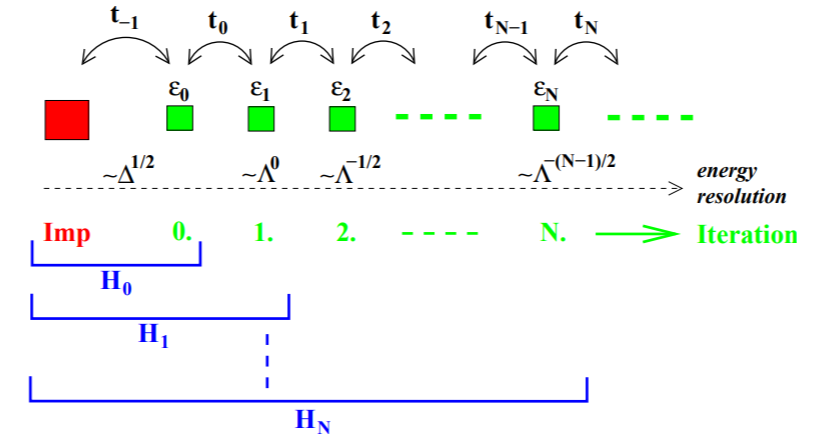

The transformations described so far are necessary to map the problem onto the semi-infinite chain, the form for which an iterative renormalization group RG procedure can be defined. This is the point at which, finally, the RG character of the approach enters.

When we rename the impurity operator $d_{\sigma} \equiv f_{-1 \sigma}$ the AM takes a particular compact form with $ t_{-1 \sigma} \equiv \sqrt{\frac{\xi_{0 \sigma}}{\pi}} $

$$ \hat{\mathcal{H}}_{A M}=\hat{\mathcal{H}}_{d}+\overbrace{\sum_{n=-1, \sigma}^{\infty}\left[t_{n \sigma}\left(f_{n \sigma}^{\dagger} f_{n+1 \sigma}+f_{n+1 \sigma}^{\dagger} f_{n \sigma}\right)+\epsilon_{n+1 \sigma} f_{n+1 \sigma}^{\dagger} f_{n+1 \sigma}\right]}^{\hat{H}_{CB}+\hat{H}_{ld}} $$

The chain Hamiltonian can be viewed as a series of Hamiltonians $H_{N}$,N=0,1,2,... which approaches H in the limit $N \rightarrow \infty$ :

$$ H=\lim _{N \rightarrow \infty} \Lambda^{-(N-1) / 2} H_{N} $$

with $$ \begin{aligned} H_{N}=& \Lambda^{(N-1) / 2}\left(H_{\mathrm{imp}}+\sqrt{\frac{\xi_{0}}{\pi}} \sum_{\sigma}\left(f_{\sigma}^{\dagger} c_{0 \sigma}+c_{0 \sigma}^{\dagger} f_{\sigma}\right)\right.\\ &\left.+\sum_{\sigma n=0}^{N} \varepsilon_{n} c_{n \sigma}^{\dagger} c_{n \sigma}+\sum_{\sigma n=0}^{N-1} t_{n}\left(c_{n \sigma}^{\dagger} c_{n+1 \sigma}+c_{n+1 \sigma}^{\dagger} c_{n \sigma}\right)\right) \end{aligned} $$

Two successive Hamiltonians are related by

$$ \begin{aligned} H_{N+1}=& \sqrt{\Lambda} H_{N}+\Lambda^{N / 2} \sum_{\sigma} \varepsilon_{N+1} c_{N+1 \sigma}^{\dagger} c_{N+1 \sigma} \\ &+\Lambda^{N / 2} \sum_{\sigma} t_{N}\left(c_{N \sigma}^{\dagger} c_{N+1 \sigma}+c_{N+1 \sigma}^{\dagger} c_{N \sigma}\right) \end{aligned} $$

and the starting point of the sequence of Hamiltonians is given by

$$ \begin{aligned} H_{0}= \Lambda^{-1 / 2}\left(H_{\mathrm{imp}}+\sum_{\sigma} \varepsilon_{0} c_{0 \sigma}^{\dagger} c_{0 \sigma}\right. \left.+\sqrt{\frac{\xi_{0}}{\pi}} \sum_{\sigma}\left(\dot{f}_{\sigma}^{\dagger} c_{0 \sigma}+c_{0 \sigma}^{\dagger} f_{\sigma}\right)\right) \end{aligned} $$

The latter equation defines a transformation R that (i) relates effective Hamiltonians on successive lower energy scales with each other and (ii) couples only neighboring sites along the (Wilson) chain

The taste of the renormalization group gradually shows up.

For the particular case, i.e. flat and spin-independent bands, the result is recovered with

$$ t_{n \sigma}=\frac{1}{2}\left(1+\Lambda^{-1}\right) \Lambda^{-n / 2} \frac{1-\Lambda^{-n-1}}{\sqrt{\left(1-\Lambda^{-2 n-1}\right)\left(1-\Lambda^{-2 n-3}\right)}} $$

Note that the energy resolution in the N-th iteration is of order $\sim \Lambda^{-(N-1) / 2}$ . The rescaling factor $ \Lambda^{-(N-1) / 2}$ ensures that $ H^N $ contains numbers that are ∼ O(1), i.e. numerically “good” numbers. $ H^N $ is an effective Hamiltonian that captures the physics at a temperature $ kBT/D \sim \Lambda^{-(N-1) / 2}$. Lower temperatures are reached when one proceeds along the Wilson chain.

- BASIC NOTIONS OF RENORMALIZATION GROUP

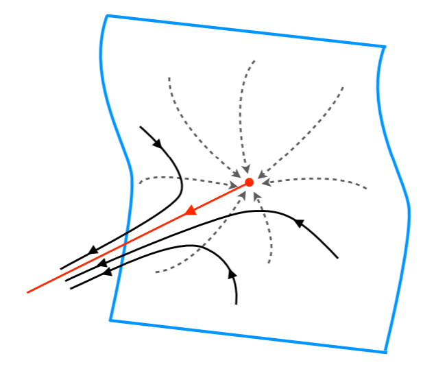

When we say “effective Hamiltonian”, what we mean is a description of system properties on the energy/temperature/length scale of our interest. The terms of the effective Hamiltonian are selected based on symmetry considerations and the relevant excitations, while the parameters are very often extracted from the experiment. For example, a magnetic insulator can be described using the Heisenberg model with the exchange coupling constant J determined from the hightemperature Curie’s law behaviour of magnetic susceptibility. One would then apply this effective model to study the low-temperature magnetic phases of the system. *

A systematic way of finding relations between the effective descriptions of the same physical system on different scales is known as the renormalization group (RG). The RG provides both an operational procedure for finding such relations and a framework for discussing and describing these relations. The basic idea is that the effective Hamiltonians on two different scales can be related by some transformation T, so that

$$ H_{N+1}=T\left[H_{N}\right] $$

where HN is the Hamiltonian at the energy scale indexed by N. The transformation T can be iterated, but in most cases it is not invertible, thus the mathematical structure is actually that of a semigroup rather than a group.

The key step in the analysis is the identification of the fixed points of the mapping T, i.e.$ H^{*}=T\left[H^{*}\right] $, *Assuming that a Hamiltonian HN is close to such a fixed point, we may expand as H

$$ \begin{aligned} H_{N}=& H^{*}+\delta H_{N} \\ H_{N+1}=&T\left[H^{*}+\delta H\right]=H^{*}+L\left[H^{*}\right] \cdot \delta H+\mathcal{O}\left[\delta H_{N}^{2}\right] & \\ & L\left[H^{*}\right] \cdot O=\lambda O \\ \delta H_{N}&=\sum_{m} c_{m} \lambda_{m}^{N} O_{m} \end{aligned} $$

Here $L\left[H^{*}\right]$ is the linearization of T around the point $H^*$ in the space of Hamiltonians. This mapping admits eigenoperators $O_m $ and eigenvalues $λ_m$. Thus the generic solution in the vicinity of $H^*$ can be expanded with the coefficients cm determined by the expansion of the initial Hamiltonian $H_{1}$.

Clearly, if $\lambda_m >1$, the contribution of the m-th term will grow. Such operators $O_m$ are known as relevant operators. They describe the flow away from the fixed point, i.e., the cross-over to a different type of behaviour (provided of course that the m-th term is actually present, i.e., $c_m \neq 0$). To the contrary, if $\lambda_m < 1$, the m-th term will become small. Such operators are called irrelevant operators. If a fixed point only has irrelevant operators, it is a stable fixed point that has universal behaviour. The special case of $\lambda_m = 1$ requires a more involved analysis based on an expansion to higher order in $\delta H_{N}$ . For example, fixed points may form lines of fixed points if the operator is exactly marginal.

> THe skeleton of the Renormalization Group
> - The sequence of Hamiltonians,$H_{N}$ , form a group(semi-group ).
> - Application of the transformation, $ \hat{R}\left(H_{N}\right) $ , generates a new member of the group $H_{N+1}$ ,
> - Successive application of the transformation generates a characteristic RG flow through this Hamiltonian space

```
Flow starts from the ‘initial’ Hamiltonian (corresponding to the bare impurity with its original microscopic parameters)

At special points in the flow, physics can be understood in terms of the original model, but with renormalized parameters.
```

> - Fixed points (FPs) of the RG transformation correspond to special cases where $ H^{*}=\hat{R}\left(H^{*}\right) $

```
A fixed point Hamiltonian is thus one that is invariant to the RG transformation $H_N=H_{N+1}=H^{*}$

Fixed point Hamiltonians often correspond to the original model, but with special renormalized values of the parameters (often 0 or infinity, but not always)
```

> - Analyze behavior near to FPs:

$$ H_N=H^{*}+ \Delta H_N\\ H_{N+1}=H^{*}+ \Delta H_{N+1}\\ H_{N+1}=\hat{R} H_N\\ \Delta H_{N+1}=\hat{R}(\Delta H_N ) $$

```
Does \$Delta H_N$ get larger or smaller with N ?

>  Construct possible perturbations to each FP consistent with model symmetries
```

$$ \Delta H_{N}=\sum_{i} a_{i} \lambda_{i}^{N} \hat{O}_{i} $$

```
> Can determine eigenvalue $\lambda_{i}$ of the transformation for operators $\hat{O}_{i}$ analytically!
```

> - Classify fixed points as ‘stable’ or ‘unstable’:
- A ‘stable’ FP has no relevant perturbations --- RG flow ‘attracted’ to the FP
- An ‘unstable’ FP has at least one relevant perturbation --- RG flow ‘repelled’ by the FP

###### A glimpse of the beauty of RG Flow

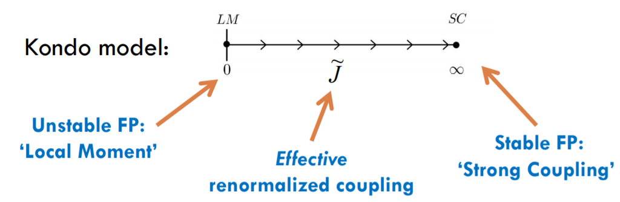

RG flow between fixed points

 Repelled by unstable FPs; attracted by stable FPs

 Seen in many-particle energies and physical quantities

 Schematically represented by RG flow diagram

- Number, character and stability of FPs determined by the specific RG transformation and symmetries
- RG flow (trajectory) determined by starting parameters of bare model

> One stable FP:

> ```
> - Single ground state!
> - For any starting parameters, always end up at the same FP (although path to reach the stable FP might be different)
> ```

> Universality

> ```
> - Irrespective of the details of a model, or its bare parameters,two systems with the same stable fixed point have the same ground state and low-energy physics
> - RG flow between two fixed points is universal, and characterized only by a single crossover energy scale (for example, TK for the Kondo model)
> - Physical quantities for different systems are described by a single universal curve, when rescaled in terms of T/TK or ω/TK
> ```

> Two stable FP:
- Two possible ground states
- Starting parameters --- determine RG trajectory and ultimately which stable FP is reached
- Quantum phase transition!

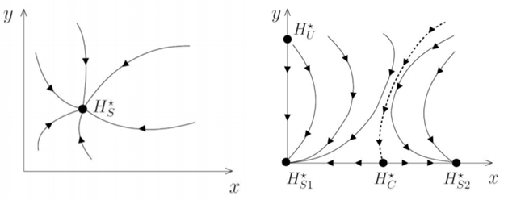

> Fixed point properties
- Free Wilson Chain is invariant under the RG transformation

$$ H_{\text {host}}=\hat{R}^{2}\left(H_{\text {host}}\right) $$

- Free Wilson Chain (no impurity):

$$ H_{N}^{W C}=\Lambda^{(N-1) / 2} \sum_{\sigma} \sum_{n=0}^{N} e_{n} f_{n \sigma}^{\dagger} f_{n \sigma}+\sum_{n=0}^{N-1}\left(h_{n} f_{n \sigma}^{\dagger} f_{(n+1) \sigma}+\mathrm{H.c.}\right) $$

- Represented by tridiagonal matrix

$$ \Lambda^{(N-1) / 2} \times\left(\begin{array}{cccc} {e_{0}} & {h_{0}} & {} & {} \\ {h_{0}} & {e_{1}} & {h_{1}} & {} \\ {} & {h_{1}} & {e_{2}} & {\ddots} \\ {} & {} & {\ddots} & {\ddots} \end{array}\right) $$

- Diagonalize matrix to obtain single-particle levels:

$$ H_{N}^{W C}=\sum_{k, \sigma} \varepsilon_{k} b_{k \sigma}^{\dagger} b_{k \sigma} $$

```
Fill up single-particle levels up to the Fermi level(in accordance with Pauli principle)

Construct manyparticle excitations above ground state

Rapid convergence with Wilson Chain length: adding more sites does not change levels!
```

- Free Wilson chain is a FP of the RG transformation!
- Anderson Impurity Model: reminder

$$ H=\varepsilon\left(\hat{n}_{i m p}^{\uparrow}+\hat{n}_{i m p}^{\downarrow}\right)+U\left(\hat{n}_{i m p}^{\uparrow} \hat{n}_{i m p}^{\downarrow}\right)+\sum_{k, \sigma} \varepsilon_{k} \hat{n}_{k}^{\sigma}+V \sum_{k, \sigma}\left(d_{\sigma}^{\dagger} c_{k, \sigma}+\mathrm{H.c.}\right) $$

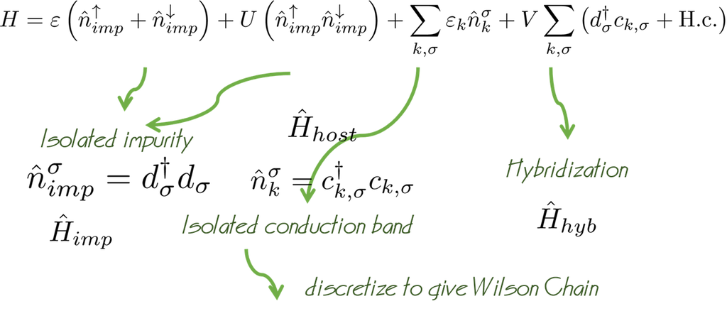

> FPs Hamiltonians are of the same form, but with renormalized parameters:
> 1. Free Orbital (FO) FP (high T) Free Wilson chain with a single decoupled impurity SITE

> $H_{F O}^{*}=H \quad$ with $\quad V_{F O}^{*}=0 ; \quad U_{F O}^{*}=0 ; \quad \varepsilon_{F O}^{*}=0$
> 1. Local Moment (LM) FP (T ~ U : Schrieffer-Wolff)

> $H_{L M}^{*}=H \quad$ with $\quad V_{L M}^{*}=0 ; U_{L M}^{*}=\infty ; \quad \varepsilon_{L M}^{*}=-U_{L M}^{*} / 2$
- Schrieffer-Wolff transformation

> Local Moment resonance state: singly occupied, $< n \dagger = 1>$ --- for the particular choice of $\epsilon _{d}$ the emty and doubly occupied states can be regarded.
- $\sigma = \Uparrow / \Downarrow $ corresponds to a spin $\sigma$ electron in the impurity.

$$\hat{\mathbf{S}} \equiv \frac{1}{2} \sum_{\mu \nu} d_{\mu}^{\dagger} \boldsymbol{\sigma}_{\mu \nu} d_{\nu}$$

- $\sigma = \uparrow / \downarrow $ corresponds to a spin $\sigma$ electron in the CB.

$\hat{\mathbf{s}}_{0} \equiv \frac{1}{2} \sum_{k k^{\prime}} \sum_{\mu \nu} \alpha_{s k \mu}^{\dagger} \boldsymbol{\sigma}_{\mu \nu} \alpha_{s k^{\prime} \nu}$

- Arrive at an effective Hamiltonian with the local (Heisenberg) coupling J between the impurity spin and the conduction electron spins.

$$\hat{\mathcal{H}}_{\mathrm{eff}}=\hat{\mathcal{H}}_{\ell}+2 J \hat{\mathbf{S}} \cdot \hat{\mathbf{s}}_{0}$$

> 1. Strong Coupling (SC) FP (low temperature… T << TK)

> $H_{S C}^{*}=H \quad$ with $\quad\left(V_{S C}^{*}\right)^{2} / U_{S C}^{*}=\infty ; \quad \varepsilon_{S C}^{*}=-U_{S C}^{*} / 2$

> Free Wilson chain with ‘zero-orbital’ removed

###### LM fixed point analysis

> 1.Near the FO FP:

$$ \begin{aligned} &H_{N}^{F O}=H_{F O}^{*}+\Delta H_{N}^{F O}\\ &\Delta H_{N}^{F O}=\sum_{i} a_{i} \lambda_{i}^{N} \hat{O}_{i} \end{aligned} $$

- relevant --- FO FP unstable!

$$ \begin{aligned} &\hat{O}_{1}=\left(d_{\sigma}^{\dagger} d_{\sigma}-1\right)^{2}\\ &\hat{O}_{2}=\left(d_{\sigma}^{\dagger} f_{0, \sigma}+f_{0, \sigma}^{\dagger} d_{\sigma}\right) \end{aligned} $$

> 2.Near the LM FP:

$$ H_{N}^{L M}=H_{L M}^{*}+\Delta H_{N}^{L M} $$

-marginally relevant: LM FP unstable

$$ \hat{O}_{1}=\left(f_{0, \sigma}^{\dagger} \vec{\sigma} f_{0, \sigma^{\prime}}\right) \cdot \vec{\tau} $$$$ \begin{aligned} H^{e f f} =\Lambda^{(N-1) / 2} \sum_{n=0}^{N-1} \sum_{\sigma} h_{n} f_{n \sigma}^{\dagger} f_{(n+1) \sigma}+\mathrm{H.c.} +\widetilde{J} \Lambda^{(N-1) / 2}\left(f_{0, \sigma}^{\dagger} \vec{\sigma} f_{0, \sigma^{\prime}}\right) \cdot \vec{\tau} \end{aligned} $$

> 1. Near the SC FP:

$$ H_{N}^{S C}=H_{S C}^{*}+\Delta H_{N}^{S C} $$

- irrelevant

$$ \begin{aligned} &\hat{O}_{1}=\left(f_{1, \sigma}^{\dagger} f_{2, \sigma}+f_{2, \sigma}^{\dagger} f_{1, \sigma}\right)\\ &\hat{O}_{2}=\left(f_{1, \sigma}^{\dagger} f_{1, \sigma}-1\right)^{2} \end{aligned} $$

- SC FP is ‘stable’
- As N increases, get closer to SC FP
- MUST reach SC FP at low enough temperatures
- T=0 ground state is described by SC FP: Kondo singlet

> Schematic RG flow diagram:

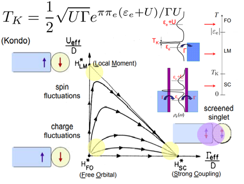

- For T<TK , local spin screened into singlet: “Kondo effect”
- local density of states develops “Kondo resonance”
- other electrons experience strong phase shift

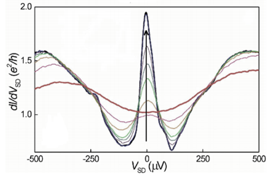

**THE Essence of Iterative diagonalization**

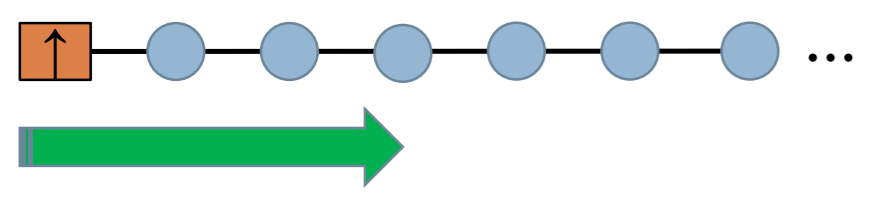

> Idea in NRG: diagonalize the chain iteratively

Throw away unimportant states at each step (successively truncate the Hilbert space)

> - Take the ‘generic’ tight-binding 1d chain

$$ H_{N}=\sum_{i=0}^{N-1} \sum_{\sigma} t_{i} c_{i \sigma}^{\dagger} c_{(i+1) \sigma}+\mathrm{H.c.}+\varepsilon_{i} c_{i \sigma}^{\dagger} c_{i \sigma} $$

> - Strategy: build up chain successively by adding on extra sites. Start by diagonalizing the dimer:

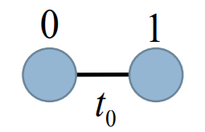

>   $$ H_{1}=\sum_{\sigma} t_{0} c_{0 \sigma}^{\dagger} c_{1 \sigma}+\mathrm{H.c.} $$
> - Building the blocks

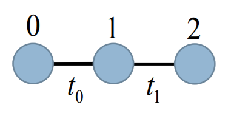

>   $$ H_{2}=\sum_{\sigma} t_{0} c_{0 \sigma}^{\dagger} c_{1 \sigma}+t_{1} c_{1 \sigma}^{\dagger} c_{2 \sigma}+\mathrm{H.c.} $$
> - Recursion:

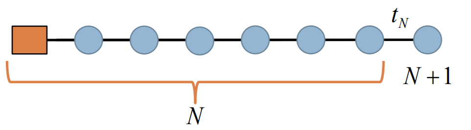

$$ \begin{aligned} &H_{N+1}=H_{N}+H_{N+1}^{h o p}\\ &H_{N+1}^{h o p}=\sum_{\sigma} t_{N} c_{N \sigma}^{\dagger} c_{(N+1) \sigma}+\mathrm{H.c.} \end{aligned} $$

> - Use the diagonal basis of iteration N and couple on an extra site. Then re-diagonalize.
> - first ,define matrix product states:

$$ |N+1 ; k, r\rangle_{b s}=|N+1 ; k\rangle_{a} \otimes|N ; r\rangle_{d} $$

> - Basis states for iteration N+1 takes the shape of a direcct product of basis states of a single added states and diagonal states of previous iteration N.
> - States of added site defined by:

$$ \begin{aligned} &|N+1 ; \mathscr{k}=0\rangle_{a}=|0\rangle _{N+1}=|v a c\rangle\\ &|N+1 ; \mathscr{k}=+1\rangle_{a}=|\uparrow\rangle _{N+1}= c_{(N+1) \uparrow}^{\dagger}|v a c\rangle\\ &|N+1 ; \mathscr{k}=-1\rangle_{a}=|\downarrow\rangle _{N+1}= c_{(N+1) \downarrow}^{\dagger}|v a c\rangle\\ &|N+1 ; \mathscr{k}=2\rangle_{a}=|\uparrow \downarrow\rangle _{N+1} = c_{(N+1) \uparrow}^{\dagger} c_{(N+1) \downarrow}^{\dagger}|v a c\rangle \end{aligned} $$

> - Diagonalized states expressed as a linear combination of basis states with coefficients obtained by diagonalizing matrix $H_{N+1}$

$$ |N+1 ; r\rangle_{d}=\sum_{\mathscr{k}, r^{\prime}} U_{N+1}^{r}\left(\mathscr{k}, r^{\prime}\right)\left|N+1 ; \mathscr{k}, r^{\prime}\right\rangle_{b s} $$

> - Construct Hamiltonian: $ H_{N+1}=H_{N}+H_{N+1}^{h o p} $
> - Construct Hamiltonian:

$$ H_{N+1}=H_{N}+H_{N+1}^{h o p} $$

> - Matrix elements:

$$ \begin{aligned} &_{b s}\left\langle N+1 ; k, r\left|H_{N+1}\right| N+1 ; k^{\prime}, r^{\prime}\right\rangle_{b s} \\ =&_{d}\left\langle N ;\left.r\right|_{a}\left\langle N+1 ; k\left|H_{N+1}\right| N+1 ; k^{\prime}\right\rangle_{a} | N ; r^{\prime}\right\rangle_{d} \\ =&_{d}\left\langle N ;\left.r\right|_{a}\left\langle N+1 ; k\left|H_{N}\right| N+1 ; k^{\prime}\right\rangle_{a} | N ; r^{\prime}\right\rangle_{d} \\ +& t_{N} \sum_{\sigma} d\left\langle N ;\left.r\right|_{a}\left\langle N+1 ; k\left|c_{N \sigma}^{\dagger} c_{(N+1) \sigma}\right| N+1 ; k^{\prime}\right\rangle_{a} | N ; r^{\prime}\right\rangle_{d} \end{aligned} $$$$ \begin{array}{c} {_{d}\left\langle N ;\left.r\right|_{a}\left\langle N+1 ; k\left|H_{N}\right| N+1 ; k^{\prime}\right\rangle_{a} | N ; r^{\prime}\right\rangle_{d}} \\ =\underbrace{{_{a}\left\langle N+1 ; k | N+1 ; k^{\prime}\right\rangle_{a}}_{} \times_{d}\left\langle N ; r\left|H_{N}\right| N ; r^{\prime}\right\rangle_{d}}_{\delta _{k,k^{\prime} } \times E_{N}(r) \delta_{r,r^{\prime} } } \end{array} $$$$ t_{N} \sum_{\sigma}\left\langle N ;\left.r\right|_{a}\left\langle N+1 ; k\left|c_{N \sigma}^{\dagger} \hat{\underline{1}} c_{(N+1) \sigma}\right| N+1 ; k^{\prime}\right\rangle_{a} | N ; r^{\prime}\right\rangle_{d} $$

insert complete set of basis states:

$$ \hat{\underline{1}}=\sum_{k^{\prime \prime}, r^{\prime \prime}}\left|N+1 ; k^{\prime \prime}\right\rangle_{a}\left|N ; r^{\prime \prime}\right\rangle_{d}\left\langle N ;\left.r^{\prime \prime}\right|_{a}\left\langle N+1 ; k^{\prime \prime}\right|\right. $$$$ \begin{array}{rl} {t_{N} \sum_{\sigma} {\sum_{\mathbf{k}^{\prime}, \mathbf{r}^{\prime \prime}}}_{d}\left\langle N ;\left.r\right|_{a} \overbrace{\langle N+1 ; k|c_{N \sigma}^{\dagger}| N+1 ; k^{\prime \prime}\rangle_{a}}^{{(-1)^{k^{n}}}\overbrace{\langle N+1 ; k | N+1 ; k^{\prime \prime}\rangle}^{\delta_{k,k^{\prime \prime}}} c_{N \sigma}^{\dagger}} | N ; r^{\prime \prime}\right\rangle_{d}}\\ {\times_{d}\langle N ;r^{\prime \prime}|_{a} \underbrace{\langle N+1 ; k^{\prime \prime}|c_{(N+1) \sigma}| N+1 ; k^{\prime}\rangle_{a} | N ; r^{\prime}\rangle_{d}}_{M^{\sigma}_{k,k^{\prime \prime}}} | N ; r^{\prime}\rangle_{d}} \end{array} $$

> - Putting it all together:

$$ \begin{aligned} &_{b s}\left\langle N+1 ; k, r\left|H_{N+1}\right| N+1 ; k^{\prime}, r^{\prime}\right\rangle_{b s}\\ &=E_{N}(r) \delta_{r r^{r}} \delta_{k k^{\prime}}+t_{N} \sum_{\sigma}(-1)^{k} M_{k, k^{\prime}}^{\sigma} \times_{d}\left\langle N ; r\left|c_{N \sigma}^{\dagger}\right| N ; r^{\prime}\right\rangle_{d} \end{aligned} $$

So: iterative diagonalization requires only:

> - Trivial matrix $M^{\sigma}_{k,k^{\prime \prime}}$ which is independent of N
> - Eigenenergies of previous iteration $E_{N}(r)$
> - Matrix elements between diagonal states of previous iteration $ _{d}\left\langle N ; r\left|c_{N \sigma}^{\dagger}\right| N ; r^{\prime}\right\rangle_{d} $
- Structure of Hamiltonian matrix:

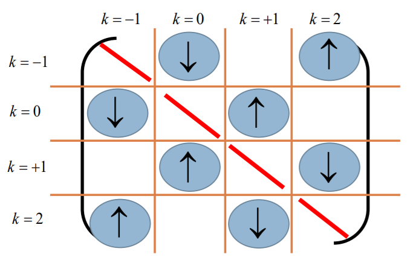

\begin{equation} \left(\begin{array}{cccc} {\sqrt{\Lambda} \hat{H}_{N}^{d}} & {t_{N \uparrow} f_{N \uparrow}^{\dagger}} & {t_{N \perp} f_{N_{l}}^{\dagger}} & {0} \\ {t_{N \uparrow} f_{N \uparrow}} & {\sqrt{\Lambda} \hat{H}_{N}^{d}+\epsilon_{N+1 \uparrow}} & {0} & {t_{N I} f_{N \perp}^{\dagger}} \\ {t_{N 1} f_{N 1}} & {0} & {\sqrt{\Lambda} \hat{H}_{N}^{d}+\epsilon_{N+1 l}} & {-t_{N \uparrow} f_{N \uparrow}^{\dagger}} \\ {0} & {t_{N 1} f_{N 1}} & {-t_{N \uparrow} f_{N \uparrow}} & {\sqrt{\Lambda} \hat{H}_{N}^{d}+\sum_{\sigma} \epsilon_{N+1 \sigma}} \end{array}\right) \end{equation}

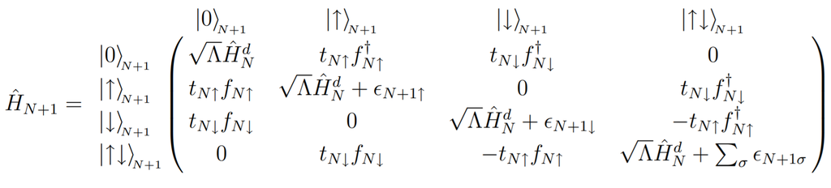

- How to calculate non-trivial matrix elements?

> First, diagonalize Hamiltonian numerically:

$$|N+1 ; r\rangle_{d}=\sum_{\vec{k}, \vec{r}} U_{N+1}^{r}(\widetilde{k}, \widetilde{r})|N+1 ; \widetilde{k}, \widetilde{r}\rangle_{b s}$$

> For the next iteration, we’ll need:

> Starting at one end of the chain, we can couple on extra sites recursively, and iteratively diagonalize.

> Obvious problem: Hilbert space grows by a factor of 4 at each iteration (fermionic sites)
> > - After only 10 sites have been added, Hamiltonian matrix in the many-particle basis is of dimension 106 x 106
> > - Diagonalization time scales as cube of matrix dimension
> > - Disaster! Must stop after only a few steps:cannot access low-energy physics this way!

#### 5. Truncation

> Exploit RG concept (which we know is at the heart of quantum impurity problems, from perturbative scaling)

> Idea in NRG: throw away high-energy states at each iteration, focusing on the low-energy physics at each step. Eventually determine ground state.

> Philosophy in NRG: Ensure coupling to each added site is always small --- logarithmic discretization

> > Mapping to a 1d chain produces hoppings that decrease exponentially down the chain.

> Energy scale separation allows truncation at every step </font>

One iteration in NRG:

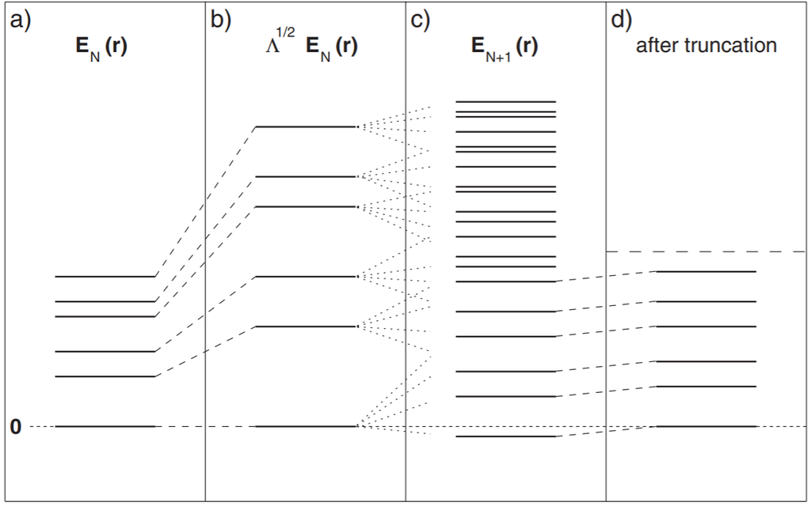

The success of the truncation scheme is intimately connected to the special structure of the chain Hamiltonian that is, $ t_{n} \propto \Lambda^{-n / 2} $ which in turn is due to the logarithmic discretization of the original model.

> NRG yields Matrix Product States $$ \begin{array}{l} {H_{k}|s\rangle_{k}=E_{s}^{k}|s\rangle_{k}} \\ {\left|s^{\prime}\right\rangle_{k+1}=\sum_{s, n_{k+1}}\left[A^{n_{k+1}}\right]_{s s^{\prime}}|s\rangle\left|n_{k+1}\right\rangle} \\ {\left|s^{\prime \prime}\right\rangle_{k+2}=\sum\left[A^{n_{k+1}} A^{n_{k+2}}\right]_{s s^{\prime \prime}}|s\rangle\left|n_{k+1}\right\rangle\left|n_{k+2}\right\rangle} \\ {\vdots} \\ {\vdots} \\ {\left|s^{\prime \prime \prime}\right\rangle_{N}=\sum\left[A^{n_{k+1}} A^{n_{k+2}} \cdots A^{n_{N}}\right]_{s s^{\prime \prime \prime}}|s\rangle\left|n_{k+1}\right\rangle\left|n_{k+2}\right\rangle \cdots\left|n_{N}\right\rangle} \end{array} $$

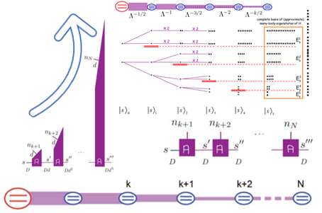

> Variational Matrix Priduct State Method (VMPS)

$$ |\psi\rangle=\sum_{\left\{n_{k}\right\}} A^{n_{1}} A^{n_{2}} A^{n_{3}} A^{n_{4}}\left|n_{1}, n_{2}, n_{3}, n_{4}\right\rangle $$$$ \partial_{A^{j}} \frac{\langle\psi|H-\lambda| \psi\rangle}{\langle\psi | \psi\rangle}=0 $$

Variationally optimize ground state in space of matrix product states.

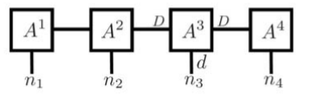

number of variantional parameters per site: $ D \times D \times d$

##### Retrospecting the analytic structure --- Wilson’s formulation

> 1. Anderson Hamiltonian:

$$\begin{aligned} \mathfrak{H} _{A} \equiv \sum_{\vec{k}} \epsilon_{\vec{k}} c_{\vec{k} \mu}^{\dagger} c_{\vec{k} \mu}+\epsilon_{d} c_{d \mu}^{\dagger} c_{d \mu}+U\left(c_{d \uparrow}^{\dagger} c_{d \uparrow}\right)\left(c_{d \downarrow}^{\dagger} c_{d \downarrow}\right) +\sum_{\vec{k}}\left(V_{\vec{k} d} c_{\vec{k} \mu}^{\dagger} c_{d \mu}+V_{\vec{k} d}^{*} c_{d \mu}^{\dagger} c_{\vec{k} \mu}\right) \end{aligned}$$

> 1. Conduction band assumed to be isotropic:
> - $\boldsymbol{\epsilon}_{\overrightarrow{\mathrm{k}}}$ depends only on $|\overrightarrow{\mathrm{k}}|$
> - $V_{\overrightarrow{\mathrm{k}} d}$ depends only on $|\overrightarrow{\mathrm{k}}|$
> - Impurity then just couples to the s-wave states: $$ \begin{aligned} \mathfrak{H}_{A}=\int_{-D}^{D} \epsilon a_{\epsilon \mu}^{\dagger} a_{\epsilon \mu} d \epsilon+\epsilon_{d} c_{d \mu}^{\dagger} c_{d \mu}+U\left(c_{d \uparrow}^{\dagger} c_{d \dagger}\right)\left(c_{d \downarrow}^{\dagger} c_{d l}\right) +\int_{-D}^{D} d \epsilon[\rho(\epsilon)]^{1 / 2}\left[V_{d}(\epsilon) a_{\epsilon \mu}^{\dagger} c_{d \mu}+V_{d}^{*}(\epsilon) c_{d \mu}^{\dagger} a_{\epsilon \mu}\right] \end{aligned} $$
> - Assume and are $ \rho(\varepsilon) \equiv \rho \text { and } V_{d}(\varepsilon) \equiv V_{d} $ independent of energy (and write $ k=\epsilon / D $ , $ \Gamma \equiv \pi \rho V_{d}^{2} $ ).

$$ \begin{aligned} \mathfrak{H} _{\mathcal{A}}=& D\left(\int_{-1}^{1} k a_{k \mu}^{\dagger} a_{k \mu} d k+\epsilon_{d} c_{d \mu}^{\dagger} c_{d \mu}+U\left(c_{d \uparrow}^{\dagger} c_{d \uparrow}\right)\left(c_{d \downarrow}^{\dagger} c_{d \downarrow}\right)\right.\\ &\left.+\left(\frac{\Gamma}{\pi D}\right)^{1 / 2} \int_{-1}^{1} d k\left(a_{k \mu}^{\dagger} c_{d \mu}+c_{d \mu}^{\dagger} a_{k \mu}\right)\right) \end{aligned} $$

> 1. Divide band into logarithmic intervals: $$ P_{n}=\pm \Lambda^{-n} \quad \text { with } n=0,1,2,3,4, \dots $$
> 2. Set up a Fourier series in each interval:

$$ \begin{aligned} &\psi_{n p}^{\pm}(k) \equiv\left\{\begin{array}{l} {\frac{\Lambda^{n / 2}}{\left(1-\Lambda^{-1}\right)^{1 / 2}} e^{\pm i \omega_{n} p k} \quad \text { if } \Lambda^{-(n+1)}<\pm k<\Lambda^{-n}} \\ {0 ,\quad \text { if } k \text { is outside the above interval }} \end{array}\right.\\ &\text { where, } \quad \omega_{n} \equiv \frac{2 \pi}{\Lambda^{-n}-\Lambda^{-(n+1)}}=\frac{2 \pi \Lambda^{n}}{1-\Lambda^{-1}} \end{aligned} $$

> 1. Canonical transformation of operators in each interval:

$$ \begin{aligned} &a_{k \mu}=\sum_{n p}\left[a_{n p \mu} \psi_{n p}^{+}(k)+b_{n p \mu} \psi_{n p}^{-}(k)\right]\\ &a_{n p \mu} \equiv \int_{-1}^{1} d k\left[\psi_{n p}^{+}(k)\right]^{*} a_{k \mu} ; \quad b_{n p \mu} \equiv \int_{-1}^{1} d k\left[\psi_{n p}^{-}(k)\right]^{*} a_{k \mu} \end{aligned} $$

> - Hybridization term of Hamiltonian: $$ \int_{-1}^{1} a_{k \mu} d k=\left(1-\Lambda^{-1}\right)^{1 / 2} \sum_{n} \Lambda^{-n / 2}\left(a_{n 0 \mu}+b_{n 0 \mu}\right) $$ ---Impurity only couples to p=0 fundamental harmonic!
> - BUT: Conduction electron Hamiltonian:

$$ \begin{aligned} \int_{-1}^{1} k a_{k \mu}^{\dagger} a_{k \mu} d k=& \frac{1}{2}\left(1+\Lambda^{-1}\right) \sum_{n \rho} \Lambda^{-n}\left(a_{n p \mu}^{\dagger} a_{n p \mu}-b_{n p \mu}^{\dagger} b_{n p \mu}\right) \\ &+\frac{1-\Lambda^{-1}}{2 \pi i} \sum_{n} \sum_{p \neq p} \frac{\Lambda^{-n}}{p^{\prime}-p}\left(a_{n p \mu}^{\dagger} a_{n p^{\prime} \mu}-b_{n p \mu}^{\dagger} b_{n p^{\prime} \mu}\right) \exp \frac{2 \pi i\left(p^{\prime}-p\right)}{1-\Lambda^{-1}} \end{aligned} $$

- $p\neq 0$ modes couple to impurity only indirectly, through the modes with $p = 0$
- Coupling between $p= 0$ and modes $p\neq 0$ controlled in the discretization parameter, and vanish as $\Lambda \rightarrow 1$
> - Keep only p=0 modes!

$$ \begin{aligned} \frac{\mathfrak{H}_{A}}{D} \cong & \frac{1}{2}\left(1+\Lambda^{-1}\right) \sum_{n=0}^{\infty} \Lambda^{-n}\left(a_{n \mu}^{\dagger} a_{n \mu}-b_{n \mu}^{\dagger} b_{n \mu}\right) \\ &+\frac{1}{D} \boldsymbol{\epsilon}_{d} c_{d \mu}^{\dagger} c_{d \mu}+\frac{1}{D} U\left(c_{d \uparrow}^{\dagger} c_{d \uparrow}\right)\left(c_{d \downarrow}^{\dagger} c_{d \downarrow}\right) \\ &+\left(\frac{2 \Gamma}{\pi D}\right)^{1 / 2}\left(f_{0 \mu}^{\dagger} c_{d \mu}+c_{d \mu}^{\dagger} f_{0 \mu}\right) \\ & \text { where, } f_{0 \mu}=\left[\frac{1}{2}\left(1-\Lambda^{-1}\right)\right]^{1 / 2} \sum_{n=0}^{\infty} \Lambda^{-n / 2}\left(a_{n \mu}+b_{n \mu}\right) \end{aligned} $$

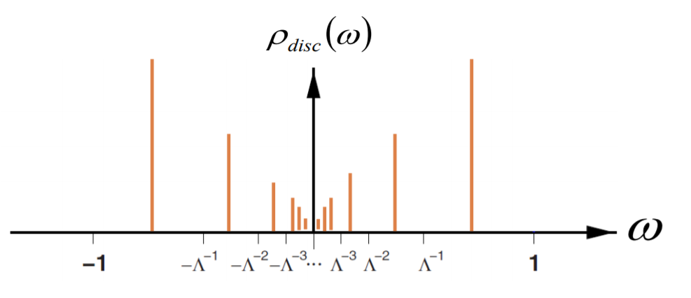

- THe fascinating core idea :

  > Low-energy excitations around Fermi level are exponentially-well sampled --- needed to capture Kondo physics on the scale of TK

  > Treats physics on all energy scales on equal footing --- Logarithmic divergences in perturbative treatment avoided by logarithmic discretization
> 1. Mapping to 1d chain -- Wilson Chain

```
   The Wilson Chain is a 1d tight-binding chain,with the impurity located at one end:
```

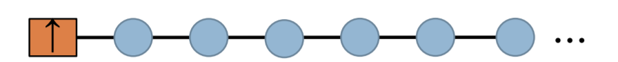

‘zero orbital’ of the Wilson Chain: Local Density of States seen by the impurity is the logarithmically discretized host density of states, $\rho _{disc} (\omega )$

$$ \begin{aligned} \rho_{d i s c}(\omega)=\sum_{k} &\left|a_{0, k}\right|^{2} \delta\left(\omega-\varepsilon_{k}\right) \\ & \Rightarrow H_{h o s t}^{d i s c}=\sum_{k, \sigma} \varepsilon_{k} b_{k \sigma}^{\dagger} b_{k \sigma} \end{aligned} $$

> 1. Tridiagonal chain representation: $$ \begin{aligned} H_{\text {host}}^{\text {disc}}=& \sum_{k, \sigma} \varepsilon_{k} b_{k \sigma}^{\dagger} b_{k \sigma} \Rightarrow \sum_{\sigma} \sum_{n}\left(h_{n} f_{n \sigma}^{\dagger} f_{(n+1) \sigma}+\text { H.c. }\right) \\ & \sum_{\sigma} \vec{b}_{\sigma}^{\dagger} \underline{D} \vec{b}_{\sigma} \Rightarrow \sum_{\sigma} \vec{f}_{\sigma}^{\dagger} \underline{W} \vec{f}_{\sigma} \end{aligned} $$

$$\left[\begin{array}{cccc}{\varepsilon_{1}} & {0} & {0} & {0} \\ {0} & {\varepsilon_{2}} & {0} & {0} \\ {0} & {0} & {\varepsilon_{3}} & {0} \\ {0} & {0} & {0} & {\varepsilon_{4}}\end{array}\right] \Rightarrow\left[\begin{array}{cccc}{e_{1}} & {h_{1}} & {0} & {0} \\ {h_{1}} & {e_{2}} & {h_{2}} & {0} \\ {0} & {h_{2}} & {e_{3}} & {h_{3}} \\ {0} & {0} & {h_{3}} & {e_{4}}\end{array}\right]\\ \underline{D} \qquad \qquad \qquad \qquad \underline{W} $$

> - Tridiagonalize by “Lanczos” method

```
 CONSTRAINT: zero-orbital of Wilson chain must have correct LDOS
```

$$\rho_{d isc}(\omega)=\sum_{k}\left|a_{0, k}\right|^{2} \delta\left(\omega-\varepsilon_{k}\right)$$

$\left|a_{0, k}\right|^{2}$ --- pole weights define the $\quad$ transformation for the zero-orbital,connected to the impurity

Lanczos starting vector $\left|a_{0}\right\rangle$

Starting ingredients: diagonal host Hamiltonian and zero-orbital vector

$$H_{\text {host}}^{d i s c}=\sum_{k, \sigma} \varepsilon_{k} b_{k \sigma}^{\dagger} b_{k \sigma}\qquad \qquad \left|a_{0}\right\rangle$$

Compute:

$$ \begin{aligned} &H\left|a_{0}\right\rangle= e_{1}\left|a_{0}\right\rangle+ h_{1}\left|a_{1}\right\rangle\\ &H\left|a_{1}\right\rangle= h_{1}\left|a_{0}\right\rangle+ e_{1}\left|a_{1}\right\rangle+ h_{2}\left|a_{2}\right\rangle \end{aligned} $$

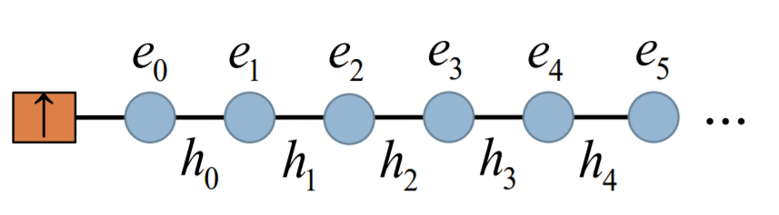

$$ \left\langle a_{i}|H| a_{i}\right\rangle= e_{i} \quad \text { and } \quad\left\langle a_{i}|H| a_{i-1}\right\rangle= h_{i} $$

Wilson showed that the hoppings drop off exponentially down the chain, due to the logarithmic discretization:

$$ h_{n} \sim \Lambda^{-n / 2} $$

> 1. Iterative diagonalization of Wilson chain and Truncation of Hilbert space at each step

```
 Throw away high lying states, keeping large but fixed number, Ns , states per iteration


 Justified by the energy-scale separation going from iteration to iteration


 High-energy states discarded at one iteration do not affect low-energy states at later iterations
```

### Physical quantities.

> NRG: recap

```
- Logarithmic discretization of conduction band
- Mapping to 1d Wilson chain
- Iterative diagonalization
- Successive Hilbert space truncation

     Keep a large but finite number of states at each iteration (discard the high-energy states):

     Access ground state information(in a finite number of steps)
```

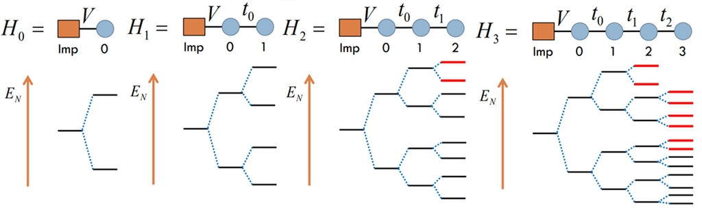

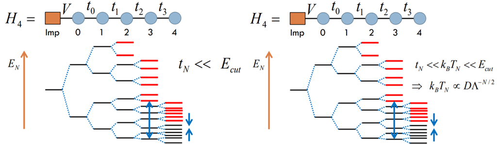

> We recover the full (discretized) Hamiltonian only in the limit

$$ H=\lim _{N \rightarrow \infty} \Lambda^{-(N-1) / 2} H_{N} $$

> the sequence of approximate Hamiltonians for finite N=0, 1, 2, 3, … accurately describe the full system at an effective temperature $ k_{B} T_{N} \propto D \Lambda^{-N / 2} $

> Useful information can be extracted at each iteration!

> Thermodynamics can be calculated from the finite set of NRG energy levels at a given iteration for this temperature

> Dynamic quantities

thermodynamics:

$$Z=\operatorname{Tr}\left[e^{-\beta H}\right]=\sum_{n} e^{-\beta E_{n}} \quad \beta=\frac{1}{k_{B} T}$$

dynamics:

\begin{aligned} x(t)=\int_{-\infty}^{t} \chi\left(t-t^{\prime}\right) h\left(t^{\prime}\right) \mathrm{d} t \\ \chi\left(t-t^{\prime}\right)=-i\left\langle\left[A(t), B\left(t^{\prime}\right)\right]\right\rangle \end{aligned}

Green’s functions

$$ \begin{aligned} G_{A B}(t)=\langle\langle A, B\rangle\rangle_{t} \equiv-i \theta(t)\left\langle[A(t), B(0)]_{\pm}\right\rangle & A(t)=e^{i H t} A e^{-i H t} \\ G_{A B}(z)=\langle\langle A, B\rangle\rangle_{z}=\int_{0}^{\infty} e^{i z t} G_{A B}(t) d t, & \Im z>0 \end{aligned} $$

Spectral theorem:

$$\rho_{A B}(\omega)=-\frac{1}{2 \pi i}\left(G_{A B}(\omega+i \delta)-G_{A B}(\omega-i \delta)\right) \equiv-\frac{1}{\pi} G_{A B}^{\prime \prime}(\omega)$$$$ G_{A B}(z)=\int_{-\infty}^{\infty} \frac{\rho_{A B}(\omega)}{z-\omega} d \omega $$

Correlation functions:

$$C_{A B}^{>}=\langle A(t) B\rangle \quad C_{A B}^{<}=\langle B A(t)\rangle$$\begin{array}{c} {C_{A B}^{>.<}(\omega)=\int_{-\infty}^{\infty} e^{i \omega t} C_{A B}^{>,<}(t)} \\ {G_{A B}(t)=-i \theta(t)\left(C_{A B}^{>}(t)+\epsilon C_{A B}^{<}(t)\right)}\\ \varepsilon=+1 \text{ if A and B are fermionic, otherwise}, \varepsilon=1 \end{array}

Lehmann representation

$$ p_{n}=e^{-\beta E_{n}} $$$$\begin{aligned} C_{A B}^{>}(t) &=\left\langle e^{i H t} A e^{-i H t} B\right\rangle=\sum_{n m} p_{n} A_{n m} B_{m n} e^{i\left(E_{n}-E_{m}\right) t} \\ C_{A B}^{>}(\omega) &=\sum_{n m} p_{n} A_{n m} B_{m n} 2 \pi \delta\left(\omega+E_{n}-E_{m}\right) \\ C_{A B}^{<}(\omega) &=\sum_{n m} p_{m} A_{n m} B_{m n} 2 \pi \delta\left(\omega+E_{n}-E_{m}\right) \\ G_{A B}^{\prime \prime}(\omega) &=-\pi \sum_{n m} p_{n} A_{n m} B_{m n} \delta\left(\omega+E_{n}-E_{m}\right)\left(1+\epsilon e^{-\beta \omega}\right) \end{aligned}$$$$ \rho_{A B}(\omega)=-\frac{1}{\pi} G_{A B}^{\prime \prime}(\omega) $$

Lehmann representation for impurity spectral function

$$ A(\omega)=\sum_{n m}\left|\left\langle m\left|d^{\dagger}\right| n\right\rangle\right|^{2} \delta\left(\omega-E_{m}-E_{n}\right) \frac{e^{-\beta E_{m}}+e^{-\beta E_{n}}}{Z} $$

$\square$ Entropy:

$S_{N} / k_{B}=\beta\left\langle H_{N}\right\rangle+\ln \left(Z_{N}\right)$

$\square$ Magnetic susceptibility: $\quad \chi_{N} /\left(g^{2} \mu_{B}^{2} k_{B}^{-1}\right)=\beta\left[\left\langle\left(S_{N}^{z}\right)^{2}\right\rangle-\left\langle S_{N}^{z}\right\rangle^{2}\right]$

$\square$ Specific heat:

$$ C_{N} / k_{B}=\beta^{2}\left[\left\langle\left(H_{N}\right)^{2}\right\rangle-\left\langle H_{N}\right\rangle^{2}\right] $$

> Dynamic quantities

$$ A(\omega, T)=-\frac{1}{\pi} \Im\left[\mathcal{G}^{R}(\omega, T)\right] $$$$ \mathcal{G}^{R}(t, T)=-i \theta(t) \sum_{n m} \frac{e^{-\beta E_{n}}+e^{-\beta E_{m}}}{Z(\beta)}\langle n|d(t)| m\rangle\left\langle m\left|d^{\dagger}\right| n\right\rangle $$$$ A(\omega, T)=\sum_{n m} \frac{e^{-\beta E_{n}}+e^{-\beta E_{m}}}{Z(\beta)}\left|\left\langle m\left|d^{\dagger}\right| n\right\rangle\right|^{2} \delta\left(\omega-\left(E_{m}-E_{n}\right)\right) $$$$ A(\omega, T=0)=\overbrace{\sum_{n}\left|\left\langle n\left|d^{\dagger}\right| 0\right\rangle\right|^{2} \delta\left(\omega-\left(E_{n}-E_{0}\right)\right)}^{\omega >0}+\overbrace{\sum_{n}\left|\left\langle 0\left|d^{\dagger}\right| n\right\rangle\right|^{2} \delta\left(\omega-\left(E_{0}-E_{n}\right)\right)}^{\omega <0} $$

Resort to numerical calculatons.

> References

http://www.fmt.if.usp.br/~luisdias/KondoPage/Sindel_Michael_Thesis.pdf

https://compphys.go.ro/the-numerical-renormalization-group/https://compphys.go.ro/the-numerical-renormalization-group/

http://www.physics.udel.edu/~bnikolic/QTTG/NOTES/NRG/BULLA=numerical_renormalization_group_method_for_quantum_impurity_systems.pdf

http://www.fmt.if.usp.br/~luisdias/KondoPage/Sindel_Michael_Thesis.pdf

http://www.damtp.cam.ac.uk/user/dbs26/AQFT/Wilsonchap.pdf

http://www.infis.ufu.br/~escolanrg2019/wp-content/uploads/2019/01/nrg2019.pdf

http://www.ucd.ie/nanoelectronics/nrg.html

http://www.ucd.ie/nanoelectronics/

http://www.infis.ufu.br/~escolanrg2019/wp-content/uploads/2019/01/nrg2019.pdf

http://nrgljubljana.ijs.si/

http://www.phy.bme.hu/~dmnrg/

https://link.springer.com/content/pdf/10.1007%2F978-3-642-21831-6.pdf

Still have much to learn ...